# Assignment 7

Francis Surroca

2022-08-03

```r
# Add any packages you want in this chunk:
library(plotly)
library(gamlr)
```

For this assignment, you are going to implement the LASSO regression covered in class.

You will need to reference your previous submission. We will use the previous data and your previous models.

# 1 Use Data and model from Assignment06

Bring in the data and make sure the data types are correct. If not, make the proper changes. The file is located within this project. *data/prop_prices_reduced.csv*

```r
prop_prices <- read.csv("data\\prop_prices_reduced.csv")
head(prop_prices)
```

```
##   sale_def bed bath area_heated  area dist_cbd dist_lakes pool
## 1    88142   4    2        1270  3631  5211.83     638.57    0
## 2    78046   2    2        1037  1307 14706.67     198.90    0
## 3   273777   4    2        2821 10309 20897.89    3799.20    0
## 4   229185   4    3        2341  9578  7057.41     193.39    0
## 5   464029   4    3        2981 12287  7771.70     225.97    1
## 6   109152   3    2        1307 10088 18662.69     496.94    1
```

```r
summary(prop_prices)
```

```
##     sale_def            bed             bath        area_heated
##  Min.   :  15296   Min.   :1.000   Min.   :1.000   Min.   :  650
##  1st Qu.: 115565   1st Qu.:3.000   1st Qu.:2.000   1st Qu.: 1387
##  Median : 151085   Median :3.000   Median :2.000   Median : 1744
##  Mean   : 200319   Mean   :3.398   Mean   :2.248   Mean   : 1955
##  3rd Qu.: 213902   3rd Qu.:4.000   3rd Qu.:2.500   3rd Qu.: 2301
##  Max.   :7629992   Max.   :7.000   Max.   :8.000   Max.   :10796
##       area           dist_cbd         dist_lakes           pool
##  Min.   :  1307   Min.   :  598.2   Min.   :  16.74   Min.   :0.000
##  1st Qu.:  6498   1st Qu.: 9701.7   1st Qu.: 314.86   1st Qu.:0.000
##  Median :  8733   Median :14552.0   Median : 638.82   Median :0.000
##  Mean   : 10565   Mean   :14382.9   Mean   :1403.54   Mean   :0.229
##  3rd Qu.: 11250   3rd Qu.:19369.2   3rd Qu.:1735.35   3rd Qu.:0.000
##  Max.   :269496   Max.   :36107.6   Max.   :8206.79   Max.   :1.000
```

```r
prop_prices$lake_front <- prop_prices$dist_lakes
prop_prices$lake_front[prop_prices$lake_front < 100] = 1
prop_prices$lake_front[prop_prices$lake_front > 100] = 0

prop_prices$downtown <- prop_prices$dist_cbd
prop_prices$downtown[prop_prices$downtown < 5280] = 1
prop_prices$downtown[prop_prices$downtown > 5280] = 0

prop_prices$luxury = 0
prop_prices$luxury[prop_prices$bed > 4 & prop_prices$area_heated > 2500 & prop_prices$pool == 1] = 1

normalized <- subset(prop_prices, prop_prices$sale_def < 1000000)

# Use only the most significant variables in the formula
fixed_reg = glm(sale_def ~ bed + area_heated + lake_front + luxury, data=normalized)
summary(fixed_reg)
```

```
##
## Call:
## glm(formula = sale_def ~ bed + area_heated + lake_front + luxury,
##     data = normalized)
##
## Deviance Residuals:
##     Min       1Q   Median       3Q      Max
## -261811   -33253    -3773    22079   588465
##
## Coefficients:
##               Estimate Std. Error t value Pr(>|t|)
## (Intercept)   8472.054  10191.716   0.831   0.4060
## bed         -27164.364   3827.722  -7.097 2.44e-12 ***
## area_heated    137.089      3.938  34.816  < 2e-16 ***
## lake_front   45965.092   9714.313   4.732 2.55e-06 ***
## luxury       28550.211  13518.349   2.112   0.0349 *
## ---
## Signif. codes:  0 '***' 0.001 '**' 0.01 '*' 0.05 '.' 0.1 ' ' 1
##
## (Dispersion parameter for gaussian family taken to be 4530760193)
##
##     Null deviance: 1.3150e+13  on 990  degrees of freedom
## Residual deviance: 4.4673e+12  on 986  degrees of freedom
## AIC: 24853
##
## Number of Fisher Scoring iterations: 2
```

```r
coef(fixed_reg)
```

```
## (Intercept)         bed area_heated  lake_front      luxury
##   8472.0537 -27164.3638    137.0894  45965.0920  28550.2113
```

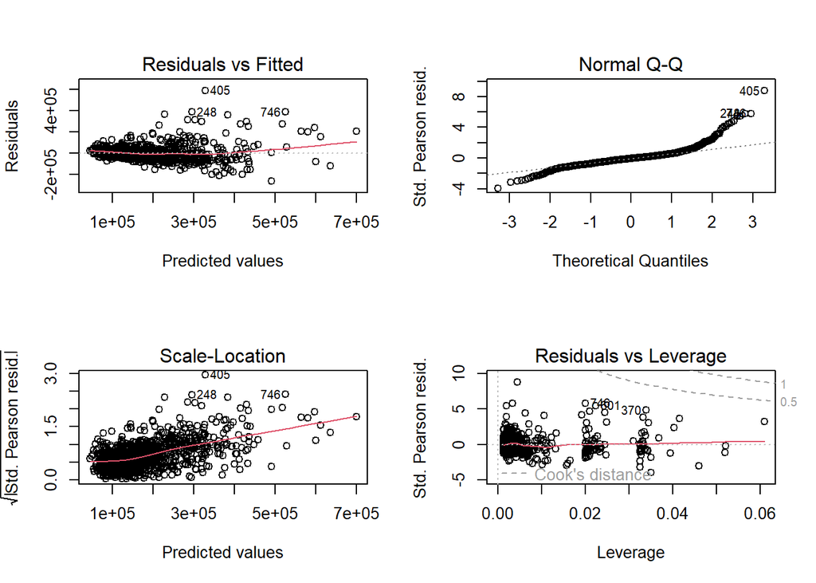

```r
par(mfrow=c(2,2))
plot(fixed_reg)
```

```r
par(mfrow=c(1,1))
```

# 2 Seperate Data into Testing and Training

This time, I want you to separate your data into testing and training. For this exercise, randomly extract 100 for testing different models, and save the other 900 for training your models.

```r
sample_row_numbers <- sample(nrow(prop_prices), size=100)
testing_df <- prop_prices[sample_row_numbers, ]
training_df <- prop_prices[-sample_row_numbers, ]
```

# 3 Run model

Run your final model you had in the previous assignment to the training data

```r
training_reg = glm(sale_def ~ bed + area_heated + lake_front + luxury, data=training_df)
summary(training_reg)
```

```
##
## Call:
## glm(formula = sale_def ~ bed + area_heated + lake_front + luxury,
##     data = training_df)
##
## Deviance Residuals:
##     Min       1Q   Median       3Q      Max
## -559684   -59489    12847    65611  4908599
##
## Coefficients:
##              Estimate Std. Error t value Pr(>|t|)
## (Intercept) -18043.44   33324.53  -0.541    0.588
## bed         -98860.43   12003.10  -8.236 6.27e-16 ***
## area_heated    277.71      10.74  25.848  < 2e-16 ***
## lake_front  152516.30   31713.63   4.809 1.78e-06 ***
## luxury      181959.13   41492.01   4.385 1.30e-05 ***
## ---
## Signif. codes:  0 '***' 0.001 '**' 0.01 '*' 0.05 '.' 0.1 ' ' 1
##
## (Dispersion parameter for gaussian family taken to be 41327204599)
##
##     Null deviance: 8.1584e+13  on 899  degrees of freedom
## Residual deviance: 3.6988e+13  on 895  degrees of freedom
## AIC: 24561
##
## Number of Fisher Scoring iterations: 2
```

```r
coef(training_reg)
```

```
## (Intercept)         bed area_heated  lake_front      luxury
## -18043.4376 -98860.4261    277.7069 152516.3044 181959.1300
```

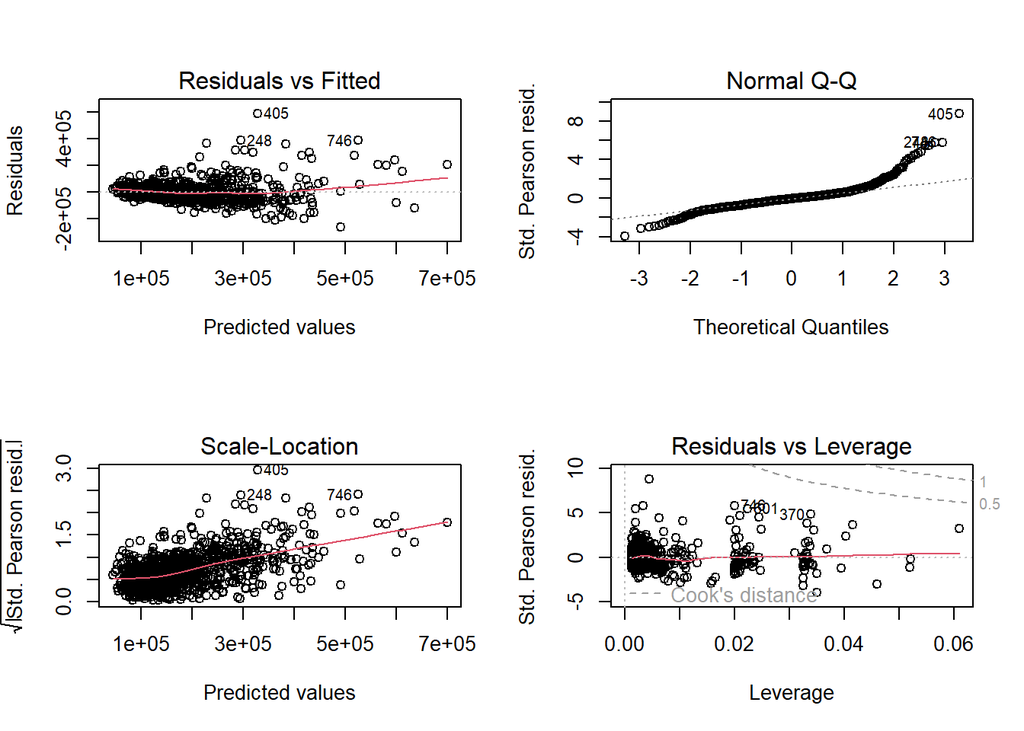

```r
par(mfrow=c(2,2))
plot(fixed_reg)
```

```r
par(mfrow=c(1,1))
```

# 4 LASSO

With the same model in part 2, run the standard LASSO regression model on the training data.

```r
training_response <- data.matrix(training_df$sale_def)
training_data_matrix <- data.matrix(training_df[ , c('bed','area_heated','lake_front','luxury')])
result <- gamlr(training_data_matrix, log(training_response), verb=TRUE)
```

```
## *** n=900 observations and p=4 covariates ***
## segment 1: lambda = 0.4685, dev = 273.1, npass = 0
## segment 2: lambda = 0.4472, dev = 255.6, npass = 3
## segment 3: lambda = 0.4268, dev = 239.6, npass = 3
## segment 4: lambda = 0.4074, dev = 225, npass = 3
## segment 5: lambda = 0.3889, dev = 211.8, npass = 3
## segment 6: lambda = 0.3712, dev = 199.7, npass = 3
## segment 7: lambda = 0.3544, dev = 188.7, npass = 3
## segment 8: lambda = 0.3383, dev = 178.6, npass = 3
## segment 9: lambda = 0.3229, dev = 169.5, npass = 3
## segment 10: lambda = 0.3082, dev = 161.1, npass = 3
## segment 11: lambda = 0.2942, dev = 153.5, npass = 3
## segment 12: lambda = 0.2808, dev = 146.6, npass = 2
## segment 13: lambda = 0.2681, dev = 140.3, npass = 3
## segment 14: lambda = 0.2559, dev = 134.6, npass = 3
## segment 15: lambda = 0.2443, dev = 129.3, npass = 3
## segment 16: lambda = 0.2332, dev = 124.6, npass = 3
## segment 17: lambda = 0.2226, dev = 120.2, npass = 3
## segment 18: lambda = 0.2124, dev = 116.2, npass = 3
## segment 19: lambda = 0.2028, dev = 112.6, npass = 3
## segment 20: lambda = 0.1936, dev = 109.4, npass = 3
## segment 21: lambda = 0.1848, dev = 106.4, npass = 3
## segment 22: lambda = 0.1764, dev = 103.6, npass = 3
## segment 23: lambda = 0.1684, dev = 101.1, npass = 3
## segment 24: lambda = 0.1607, dev = 98.87, npass = 3
## segment 25: lambda = 0.1534, dev = 96.81, npass = 3
## segment 26: lambda = 0.1464, dev = 94.93, npass = 3
## segment 27: lambda = 0.1398, dev = 93.21, npass = 3
## segment 28: lambda = 0.1334, dev = 91.65, npass = 3
## segment 29: lambda = 0.1274, dev = 90.23, npass = 3
## segment 30: lambda = 0.1216, dev = 88.93, npass = 3
## segment 31: lambda = 0.116, dev = 87.75, npass = 3
## segment 32: lambda = 0.1108, dev = 86.67, npass = 3
## segment 33: lambda = 0.1057, dev = 85.69, npass = 3
## segment 34: lambda = 0.1009, dev = 84.8, npass = 3
## segment 35: lambda = 0.09634, dev = 83.98, npass = 3
## segment 36: lambda = 0.09196, dev = 83.24, npass = 3
## segment 37: lambda = 0.08778, dev = 82.57, npass = 3
## segment 38: lambda = 0.08379, dev = 81.95, npass = 3
## segment 39: lambda = 0.07998, dev = 81.39, npass = 3
```

[output cut: 46 more lines]

```
## segment 86: lambda = 0.008985, dev = 74.8, npass = 3
## segment 87: lambda = 0.008576, dev = 74.79, npass = 3
## segment 88: lambda = 0.008186, dev = 74.78, npass = 3
## segment 89: lambda = 0.007814, dev = 74.77, npass = 3
## segment 90: lambda = 0.007459, dev = 74.76, npass = 3
## segment 91: lambda = 0.00712, dev = 74.75, npass = 3
## segment 92: lambda = 0.006797, dev = 74.75, npass = 3
## segment 93: lambda = 0.006488, dev = 74.74, npass = 3
## segment 94: lambda = 0.006193, dev = 74.73, npass = 3
## segment 95: lambda = 0.005911, dev = 74.73, npass = 3
## segment 96: lambda = 0.005643, dev = 74.72, npass = 3
## segment 97: lambda = 0.005386, dev = 74.72, npass = 3
## segment 98: lambda = 0.005141, dev = 74.72, npass = 3
## segment 99: lambda = 0.004908, dev = 74.71, npass = 3
## segment 100: lambda = 0.004685, dev = 74.71, npass = 3
```

```r
summary(result)
```

```
##
## gaussian gamlr with 4 inputs and 100 segments.
```

```
##             lambda par df         r2      aicc
## seg1   0.468461002   1  1 0.00000000 -1071.162
## seg2   0.447168726   2  2 0.06423885 -1128.908
## seg3   0.426844218   2  2 0.12277090 -1187.041
## seg4   0.407443489   2  2 0.17610312 -1243.492
## seg5   0.388924554   2  2 0.22469745 -1298.205
## seg6   0.371247333   2  2 0.26897480 -1351.130
## seg7   0.354373568   2  2 0.30931867 -1402.222
## seg8   0.338266743   2  2 0.34607850 -1451.444
## seg9   0.322891997   2  2 0.37957269 -1498.765
## seg10  0.308216058   2  2 0.41009135 -1544.162
## seg11  0.294207162   2  2 0.43789881 -1587.619
## seg12  0.280834993   2  2 0.46323594 -1629.130
## seg13  0.268070609   2  2 0.48632218 -1668.696
## seg14  0.255886386   2  2 0.50735751 -1706.327
## seg15  0.244255955   2  2 0.52652412 -1742.042
## seg16  0.233154145   2  2 0.54398801 -1775.866
## seg17  0.222556929   2  2 0.55990047 -1807.832
## seg18  0.212441373   2  2 0.57439930 -1837.981
## seg19  0.202785585   2  2 0.58761010 -1866.360
## seg20  0.193568667   2  2 0.59964729 -1893.021
## seg21  0.184770672   2  2 0.61061512 -1918.021
## seg22  0.176372560   2  2 0.62060861 -1941.421
## seg23  0.168356155   2  2 0.62971430 -1963.285
## seg24  0.160704108   2  2 0.63801107 -1983.680
## seg25  0.153399858   2  2 0.64557077 -2002.675
## seg26  0.146427598   2  2 0.65245889 -2020.338
## seg27  0.139772238   2  2 0.65873509 -2036.740
## seg28  0.133419374   2  2 0.66445373 -2051.949
## seg29  0.127355257   2  2 0.66966434 -2066.034
## seg30  0.121566764   2  2 0.67441206 -2079.063
## seg31  0.116041367   2  2 0.67873800 -2091.101
## seg32  0.110767108   2  2 0.68267963 -2102.212
## seg33  0.105732572   2  2 0.68627111 -2112.456
## seg34  0.100926863   2  2 0.68954352 -2121.893
## seg35  0.096339582   2  2 0.69252523 -2130.579
## seg36  0.091960799   2  2 0.69524204 -2138.567
## seg37  0.087781039   2  2 0.69771750 -2145.907
## seg38  0.083791255   2  2 0.69997305 -2152.648
## seg39  0.079982813   2  2 0.70202823 -2158.834
```

[output cut: 46 more lines]

```
## seg86  0.008984662   3  3 0.72614878 -2232.793
## seg87  0.008576295   3  3 0.72618912 -2232.925
## seg88  0.008186489   3  3 0.72622588 -2233.046
## seg89  0.007814400   3  3 0.72625938 -2233.156
## seg90  0.007459224   3  3 0.72628990 -2233.257
## seg91  0.007120191   3  3 0.72631770 -2233.348
## seg92  0.006796567   3  3 0.72634304 -2233.431
## seg93  0.006487653   3  3 0.72636613 -2233.507
## seg94  0.006192779   3  3 0.72638716 -2233.577
## seg95  0.005911307   3  3 0.72640633 -2233.640
## seg96  0.005642629   3  3 0.72642379 -2233.697
## seg97  0.005386163   3  3 0.72643971 -2233.749
## seg98  0.005141354   3  3 0.72645420 -2233.797
## seg99  0.004907671   3  3 0.72646742 -2233.841
## seg100 0.004684610   3  3 0.72647945 -2233.880
```

```r
coef(result)
```

```
## 5 x 1 sparse Matrix of class "dgCMatrix"
##                   seg100
## intercept   1.096162e+01
## bed         .
## area_heated 5.281241e-04
## lake_front  1.333447e-01
## luxury      .
```

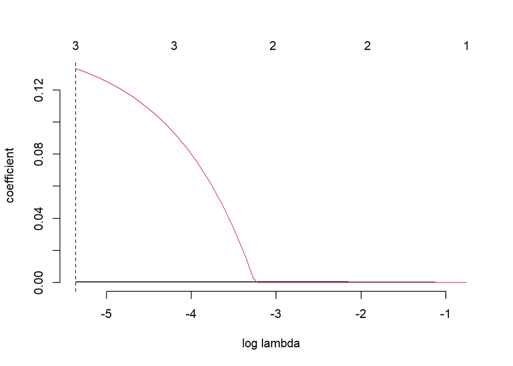

```r
plot(result) ## path plot
```